# INFO370 PS7

*Name*: Bridget Leonard \ *Collaborators*: 1) Saimanasvi Charugundla

```python
import pandas as pd
import numpy as np
import matplotlib.pyplot as plt
import statsmodels.formula.api as smf
```

# Q1.Is COMPAS fair?

## 1.1 Load and check

### 1.1.1

```python
compas = pd.read_csv("../data/compas-score-data.csv.bz2", sep="\t")
print(compas.shape)
compas.head(4)
```

```
(6172, 8)
```

|  | age | c_charge_degree | race | age_cat | sex | priors_count | decile_score | two_year_recid |
| --- | --- | --- | --- | --- | --- | --- | --- | --- |
| 0 | 69 | F | Other | Greater than 45 | Male | 0 | 1 | 0 |
| 1 | 34 | F | African-American | 25 - 45 | Male | 0 | 3 | 1 |
| 2 | 24 | F | African-American | Less than 25 | Male | 4 | 4 | 1 |
| 3 | 44 | M | Other | 25 - 45 | Male | 0 | 1 | 0 |

```python
compas.race.value_counts()
```

```
African-American    3175
Caucasian           2103
Hispanic             509
Other                343
Asian                 31
Native American       11
Name: race, dtype: int64
```

### 1.1.2

```python
races = ["African-American", "Caucasian"]
compas = compas[compas.race.isin(races)]
compas.race.value_counts()
```

```
African-American    3175
Caucasian           2103
Name: race, dtype: int64
```

## 1.2 Aggregate analysis

### 1.2.1

```python
compas["highScore"] = np.where(compas["decile_score"] < 5, 0, 1)
compas.highScore.value_counts()
```

```
0    2753
1    2525
Name: highScore, dtype: int64
```

```python
compas.head(4)
```

|  | age | c_charge_degree | race | age_cat | sex | priors_count | decile_score | two_year_recid | highScore |
| --- | --- | --- | --- | --- | --- | --- | --- | --- | --- |
| 1 | 34 | F | African-American | 25 - 45 | Male | 0 | 3 | 1 | 0 |
| 2 | 24 | F | African-American | Less than 25 | Male | 4 | 4 | 1 | 0 |
| 4 | 41 | F | Caucasian | 25 - 45 | Male | 14 | 6 | 1 | 1 |
| 6 | 39 | M | Caucasian | 25 - 45 | Female | 0 | 1 | 0 | 0 |

### 1.2.2

(a)

```python
lowRecid = np.mean(compas[compas.highScore == 0].two_year_recid)
lowRecid
```

```
0.3200145296040683
```

```python
highRecid = np.mean(compas[compas.highScore == 1].two_year_recid)
highRecid
```

```
0.6344554455445545
```

The recidivism rate for low risk offenders is 32%, while the recidivism rate for high risk offenders is 63%.

(b)

```python
aaRecid = np.mean(compas[compas.race == "African-American"].two_year_recid)
aaRecid
```

```
0.5231496062992126
```

```python
cRecid = np.mean(compas[compas.race == "Caucasian"].two_year_recid)
cRecid
```

```
0.3908701854493581
```

The recidivism rate for African American offenders is 52%, while the recidivism rate for Caucasian offenders is 39%.

### 1.2.3

```python
from sklearn.metrics import confusion_matrix
```

```python
confusion_matrix(compas.two_year_recid, compas.highScore)
```

```
array([[1872,  923],
       [ 881, 1602]])
```

Compas accurately classifies (1872 + 1602)/ 5278 = 66% percent of offenders. 881 / (881 + 1602) = 35% of offenders were falsely classified as low risk, 923 / (923 + 1602) = 37% were falsely classified as high risk.

### 1.2.4

```python
from sklearn.metrics import accuracy_score
acc = accuracy_score(compas.two_year_recid, compas.highScore)
acc
```

```
0.6582038651004168
```

```python
from sklearn.metrics import precision_score
pre = precision_score(compas.two_year_recid, compas.highScore)
pre
```

```
0.6344554455445545
```

```python
from sklearn.metrics import recall_score
rec = recall_score(compas.two_year_recid, compas.highScore)
rec
```

```
0.6451872734595248
```

```python
# fpr = fp/(tn + fp)
fpr = 923 / (1872 + 923)
fpr
```

```
0.3302325581395349
```

```python
# fnr = fn/(tp + fn)
fnr = 881 / (1602 + 881)
fnr
```

```
0.35481272654047524
```

The false positive rate measures the percentage of negative cases that are falsely categorized as positives. In this case, it would be predicting an individual will commit recidivism by classifying them as high risk when in fact, they do not. This would be problematic for a judge to do since it may lead to further restrictions being put on a person that would limit their freedom (e.g., strict parole). Attempting to predict someone's future actions leads to murky waters. Since people should only be held accountable for the crimes they have actually committed, trying to predict if they will commit more crimes in the future as part of their judgement is highly controversial. Overall, I would not feel comfortable with a judge using COMPAS to inform sentencing guidelines since about a third of the time, it predicts someone will commit a crime again when in fact they won't. This would likely lead to a harsher sentencing that is not deserved. I think I would only accept a misclassification rate of about 5%, or something very small that is likely due to chance. I think there is benefit in an algorithm if it can be better than a human judge, yet I think they should perform better because human judges can still account for context and stories behind why a person may commit a crime which may be harder for an algorithm to use as input. In this way, I think algorithms need to perform better (lower error rate) than human judges to justify their use in the criminal justice system.

## 1.3 Analysis by race

### 1.3.1

```python
highAA = np.mean(compas[(compas.race == "African-American") & (compas.highScore == 1)].two_year_recid)
highAA
```

```
0.6495352651722253
```

```python
lowAA = np.mean(compas[(compas.race == "African-American") & (compas.highScore == 0)].two_year_recid)
lowAA
```

```
0.3514115898959881
```

```python
highC = np.mean(compas[(compas.race == "Caucasian") & (compas.highScore == 1)].two_year_recid)
highC
```

```
0.5948275862068966
```

```python
lowC = np.mean(compas[(compas.race == "Caucasian") & (compas.highScore == 0)].two_year_recid)
lowC
```

```
0.2899786780383795
```

### 1.3.2

Recidivism rates for high-risk African Americans are slightly higher than recidivism rates for high-risk caucasians (about 5%). Similarly, recidivism rates for low-risk African Americans are slightly higher than recidivism rates for low-risk caucasians (about 6%). Overall, recidivism rates are about 5% higher in African Americans than caucasian regardless of risk. From these numbers, it doesn't seem like COMPAS is favoring one group over the other (there is about the same difference in recidivism rates between high and low risk for each group). In this way, COMPAS appears to be fair.

### 1.3.3

```python
cmAA = confusion_matrix(compas[compas.race == "African-American"].two_year_recid,
                        compas[compas.race == "African-American"].highScore)
cmAA
```

```
array([[ 873,  641],
       [ 473, 1188]])
```

```python
cmC = confusion_matrix(compas[compas.race == "Caucasian"].two_year_recid,
                        compas[compas.race == "Caucasian"].highScore)
cmC
```

```
array([[999, 282],
       [408, 414]])
```

#### (a) Accuracy

```python
accAA = accuracy_score(compas[compas.race == "African-American"].two_year_recid,
                        compas[compas.race == "African-American"].highScore)
accAA
```

```
0.6491338582677165
```

```python
accC = accuracy_score(compas[compas.race == "Caucasian"].two_year_recid,
                        compas[compas.race == "Caucasian"].highScore)
accC
```

```
0.6718972895863052
```

COMPAS is slightly more accurate when predicting the recidivism rates of caucasians (67%) than when classifying African Americans (65%)

#### (b) False positive rate

```python
fprAA = 641 / (873 + 641)
fprAA
```

```
0.4233817701453104
```

```python
fprC = 282 / (999 + 282)
fprC
```

```
0.22014051522248243
```

COMPAS has a much larger (almost double) false positive rate when predicting the recidivism rates of African Americans (42%) than when classifying caucasians (22%). This means that 42% of time COMPAS predicts an African American individual will commit recidivism when in fact, they will not. This large discrepancy between racial groups indicates that COMPAS is more likely to falsely classify an African American individual as high-risk than a caucasian individual.

#### (c) False negative rate

```python
fnrAA = 473 / (1188 + 473)
fnrAA
```

```
0.2847682119205298
```

```python
fnrC = 408 / (414 + 408)
fnrC
```

```
0.49635036496350365
```

COMPAS has a much larger (almost double) false negative rate when predicting the recidivism rates of caucasians (50%) than when classifying African Americans (28%). This means that 50% of time COMPAS predicts a caucasian individual will not commit recidivism when in fact, they will. This large discrepancy between racial groups indicates that COMPAS is more likely to falsely classify a caucasian individual a low-risk than an African American individual.

### 1.3.4

As I detailed in my previous answers about false positive and false negative rates, I don't think COMPAS is fair even though the accuracy measure indicates it is. This is because false positive rates are much higher for African American individuals than caucasian individuals. This indicates that COMPAS is more likely to incorrectly identify African American individuals as high risk than a caucasian individual with a similar background (input into the algorithm besides race) which could lead to unfairly harsher sentencing. In this way, COMPAS is biased against African American individuals because they are more likely to be classified as high risk when in fact they won't commit recidivism. Additionally, false negative rates are lower for African American individuals. This indicates that COMPAS is less likely to incorrectly identify African American individuals as low risk. This means caucasian individuals are more likely to get lighter sentencings because they are are more likely to be classified as low risk even though in actuality they will commit recidivism.

### 1.3.5

No my answers do not align. This is because accuracy gives us an overall look at if people are classified correctly. This is important when we value different kinds of errors equally. But most of the time, a certain kind of error is more important to reduce than the other. In this case, we want to reduce false positives because they are likely to have detrimental effects on sentencing and lead judges to make harsher sentences than what the individual actually deserves. We see that the false classification (1 - accuracy) for African American group is mostly a result of false positives (classifying them as high-risk when they are not actually). In contrast, we see that the false classification (1 - accuracy) for the caucasian group is mostly a result of false negatives (classifying them as low-risk when they are actually high-risk). Overall, COMPAS is biased towards caucasians and against African Americans (in terms of advocating for lighter sentencing) but has similar accuracy rates for each group.

# Q2.Can you beat COMPAS?

## 2.1

### 2.1.1

We want a model with high precision, that is sensitive to false positives. This is because we do not want predict someone is high-risk when they are in fact not and have this lead to a harsher sentencing than they deserve. It may be also useful to report recall since although maybe slightly less important, we want to avoid predicting someone is low-risk when in fact they commit recedivism because this could pose a threat to public safety. However, precision is still of utmost importance because our criminal justice systems lies on the ground of innocent until proven guilty which can translate over into assuming people are "lower-risk" on average.

### 2.1.2

We do not want to include decile_score because it is the output of the original COMPAS model and therefore takes into account gender and race, two predictors which we want to remove from our model.

### 2.1.3

```python
y = compas.two_year_recid
X = pd.get_dummies(compas.drop(["two_year_recid", "race", "sex", "decile_score", "highScore"], axis = 1), drop_first=True)
X.head()
```

|  | age | priors_count | c_charge_degree_M | age_cat_Greater than 45 | age_cat_Less than 25 |
| --- | --- | --- | --- | --- | --- |
| 1 | 34 | 0 | 0 | 0 | 0 |
| 2 | 24 | 4 | 0 | 0 | 1 |
| 4 | 41 | 14 | 0 | 0 | 0 |
| 6 | 39 | 0 | 1 | 0 | 0 |
| 7 | 27 | 0 | 0 | 0 | 0 |

```python
from sklearn.linear_model import LogisticRegression
m = LogisticRegression()

from sklearn.model_selection import cross_val_score

cv = cross_val_score(m, X, y, cv=10, scoring = 'precision')
cv.mean()
```

```
0.6604111653377751
```

### 2.1.4

```python
# Decision Tree - check for best depth
```

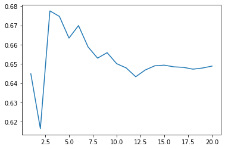

```python
from sklearn.tree import DecisionTreeClassifier

depth = range(1,21)
preAvg = []

for d in depth:
    m1 = DecisionTreeClassifier(max_depth = d)
    cv1 = cross_val_score(m1, X, y, cv=10, scoring = 'precision')
    cv1_avg = cv1.mean()
    preAvg.append(cv1_avg)

_ = plt.plot(depth, preAvg)
```

```python
# make m1 the best decision tree (depth = 3)
m1 = DecisionTreeClassifier(max_depth = 3)
cv1 = cross_val_score(m1, X, y, cv=10, scoring = 'precision')
cv1.mean()
```

```
0.6775953004881982
```

```python
# K-NN
```

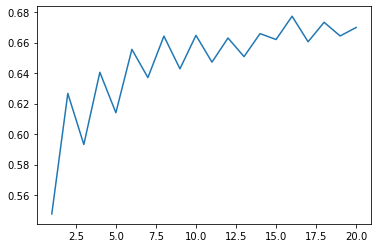

```python
from sklearn.neighbors import KNeighborsClassifier

neighbors = range(1,21)
preAvg = []

for k in neighbors:
    m2 = KNeighborsClassifier(k)
    cv2 = cross_val_score(m2, X, y, cv=10, scoring = 'precision')
    cv2_avg = cv2.mean()
    preAvg.append(cv2_avg)

_ = plt.plot(neighbors, preAvg)
```

```python
# make m2 the best K-NN model
m2 = KNeighborsClassifier(16)
cv2 = cross_val_score(m2, X, y, cv=10, scoring = 'precision')
cv2.mean()
```

```
0.6772186580591381
```

```python
# Variables
```

```
0 col dummy shape: (5278, 1)
1 col dummy shape: (5278, 2)
2 col dummy shape: (5278, 4)
3 col dummy shape: (5278, 5)
```

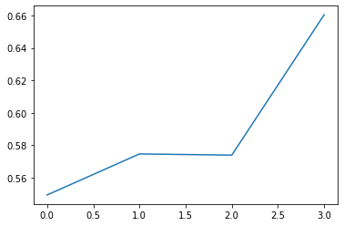

```python
# Logistic Regression
m3 = LogisticRegression()
X1 = compas.drop(["two_year_recid", "race", "sex", "decile_score", "highScore"], axis=1)

cols = range(X1.shape[1])
preAvg = []


for j in cols:
    Xj = X1.iloc[:,:j+1]
    Xd = pd.get_dummies(Xj, drop_first=True)
    print(j, "col dummy shape:", Xd.shape)
    cv = cross_val_score(m3, Xd, y, cv=10, scoring = 'precision')
    cv_avg = cv.mean()
    preAvg.append(cv_avg)

_ = plt.plot(cols, preAvg)
```

```
0 col dummy shape: (5278, 1)
1 col dummy shape: (5278, 2)
2 col dummy shape: (5278, 4)
3 col dummy shape: (5278, 5)
```

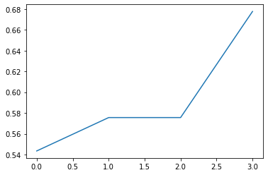

```python
# Decision Tree
m4 = DecisionTreeClassifier(max_depth = 3)

cols = range(X1.shape[1])
preAvg = []

for j in cols:
    Xj = X1.iloc[:,:j+1]
    Xd = pd.get_dummies(Xj, drop_first=True)
    print(j, "col dummy shape:", Xd.shape)
    cv = cross_val_score(m4, Xd, y, cv=10, scoring = 'precision')
    cv_avg = cv.mean()
    preAvg.append(cv_avg)

_ = plt.plot(cols, preAvg)
```

```
0 col dummy shape: (5278, 1)
1 col dummy shape: (5278, 2)
2 col dummy shape: (5278, 4)
3 col dummy shape: (5278, 5)
```

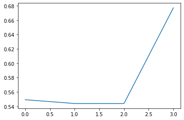

```python
# KNN
m5 = KNeighborsClassifier(16)
X1 = compas.drop(["two_year_recid", "race", "sex", "decile_score", "highScore"], axis=1)

cols = range(X1.shape[1])
preAvg = []


for j in cols:
    Xj = X1.iloc[:,:j+1]
    Xd = pd.get_dummies(Xj, drop_first=True)
    print(j, "col dummy shape:", Xd.shape)
    cv = cross_val_score(m5, Xd, y, cv=10, scoring = 'precision')
    cv_avg = cv.mean()
    preAvg.append(cv_avg)

_ = plt.plot(cols, preAvg)
```

All three models (linear regression, trees, and KNN) perform best when all variables are included. The best model I got, based on precision, was a decision tree with a max depth of 3 (precision = 67.76). This model was comparable to a KNN model that uses 16 neighbors (precision = 67.72). Both of these models had better precision than COMPAS (precision = 63.45, question 1.2.4).

## 2.2

### 2.2.1

```python
# best model is tree with 3
```

```python
# Take African American data and create matrix
```

```python
compasAA = compas[compas.race == "African-American"].copy()

yaa = compas[compas.race == "African-American"].two_year_recid
Xaa = pd.get_dummies(compasAA.drop(["two_year_recid", "race", "sex", "decile_score", "highScore"], axis = 1), drop_first=True)
print(Xaa.shape)
Xaa.head()
```

```
(3175, 5)
```

|  | age | priors_count | c_charge_degree_M | age_cat_Greater than 45 | age_cat_Less than 25 |
| --- | --- | --- | --- | --- | --- |
| 1 | 34 | 0 | 0 | 0 | 0 |
| 2 | 24 | 4 | 0 | 0 | 1 |
| 8 | 23 | 3 | 1 | 0 | 1 |
| 10 | 41 | 0 | 0 | 0 | 0 |
| 12 | 31 | 7 | 0 | 0 | 0 |

```python
# Create model and add risk prediction column to DF
```

```python
mAA = DecisionTreeClassifier(max_depth = 3)
mAA.fit(Xaa, yaa)
compasAA['risk'] = mAA.predict(Xaa)
compasAA.head()
```

|  | age | c_charge_degree | race | age_cat | sex | priors_count | decile_score | two_year_recid | highScore | risk |
| --- | --- | --- | --- | --- | --- | --- | --- | --- | --- | --- |
| 1 | 34 | F | African-American | 25 - 45 | Male | 0 | 3 | 1 | 0 | 0 |
| 2 | 24 | F | African-American | Less than 25 | Male | 4 | 4 | 1 | 0 | 1 |
| 8 | 23 | M | African-American | Less than 25 | Male | 3 | 6 | 1 | 1 | 1 |
| 10 | 41 | F | African-American | 25 - 45 | Male | 0 | 4 | 0 | 0 | 0 |
| 12 | 31 | F | African-American | 25 - 45 | Male | 7 | 3 | 1 | 0 | 1 |

```python
newhighAA = compasAA[compasAA.risk == 1].two_year_recid.mean()
newhighAA
```

```
0.7293447293447294
```

```python
newlowAA = compasAA[compasAA.risk == 0].two_year_recid.mean()
newlowAA
```

```
0.35968379446640314
```

```python
# Take Caucasian data and create matrix
```

```python
compasC = compas[compas.race == "Caucasian"].copy()

yc = compas[compas.race == "Caucasian"].two_year_recid
Xc = pd.get_dummies(compasC.drop(["two_year_recid", "race", "sex", "decile_score", "highScore"], axis = 1), drop_first=True)
print(Xc.shape)
Xc.head()
```

```
(2103, 5)
```

|  | age | priors_count | c_charge_degree_M | age_cat_Greater than 45 | age_cat_Less than 25 |
| --- | --- | --- | --- | --- | --- |
| 4 | 41 | 14 | 0 | 0 | 0 |
| 6 | 39 | 0 | 1 | 0 | 0 |
| 7 | 27 | 0 | 0 | 0 | 0 |
| 9 | 37 | 0 | 1 | 0 | 0 |
| 11 | 47 | 1 | 0 | 1 | 0 |

```python
# Create model and confusion matrix
```

```python
mC = DecisionTreeClassifier(max_depth = 3)
mC.fit(Xc, yc)
compasC["risk"] = mC.predict(Xc)
compasC.head()
```

|  | age | c_charge_degree | race | age_cat | sex | priors_count | decile_score | two_year_recid | highScore | risk |
| --- | --- | --- | --- | --- | --- | --- | --- | --- | --- | --- |
| 4 | 41 | F | Caucasian | 25 - 45 | Male | 14 | 6 | 1 | 1 | 1 |
| 6 | 39 | M | Caucasian | 25 - 45 | Female | 0 | 1 | 0 | 0 | 0 |
| 7 | 27 | F | Caucasian | 25 - 45 | Male | 0 | 4 | 0 | 0 | 0 |
| 9 | 37 | M | Caucasian | 25 - 45 | Female | 0 | 1 | 0 | 0 | 0 |
| 11 | 47 | F | Caucasian | Greater than 45 | Female | 1 | 1 | 1 | 0 | 0 |

```python
newhighC = compasC[compasC.risk == 1].two_year_recid.mean()
newhighC
```

```
0.674364896073903
```

```python
newlowC = compasC[compasC.risk == 0].two_year_recid.mean()
newlowC
```

```
0.31736526946107785
```

#### Compare old and new model values

```python
print("Recidivism rate for high risk African American")
print("COMPAS:", highAA)
print("New model:", newhighAA)
print()
print("Recidivism rate for low risk African American")
print("COMPAS:", lowAA)
print("New model:", newlowAA)
print()
print("Recidivism rate for high risk Caucasian")
print("COMPAS:", highC)
print("New model:", newhighC)
print()
print("Recidivism rate for low risk Caucasian")
print("COMPAS:", lowC)
print("New model:", newlowC)
```

```
Recidivism rate for high risk African American
COMPAS: 0.6495352651722253
New model: 0.7293447293447294

Recidivism rate for low risk African American
COMPAS: 0.3514115898959881
New model: 0.35968379446640314

Recidivism rate for high risk Caucasian
COMPAS: 0.5948275862068966
New model: 0.674364896073903

Recidivism rate for low risk Caucasian
COMPAS: 0.2899786780383795
New model: 0.31736526946107785
```

This model is more fair than COMPAS. Specifically in classifying high risk individuals, for both African American and Caucasian individuals, high risk ratings correspond to higher recidivism rates meaning the "risk" is actually being predicted better. Someone classified as "high-risk" by the new model is more likely to commit recidivism tahn someone classified as "high-risk" by COMPAS. There is little difference in recidivism rates of low risk individuals, so the new model better classifies high-risk individuals while still maintaining a similar ability as COMPAS to classify low-risk individuals.

### 2.2.2

```python
# Create African American confusion matrix
```

```python
cmAAnew = confusion_matrix(yaa, mAA.predict(Xaa))
cmAAnew
```

```
array([[1134,  380],
       [ 637, 1024]])
```

```python
fprAAnew = 380 / (380 + 1134)
fprAAnew
```

```
0.2509907529722589
```

```python
fnrAAnew = 637 / (637 + 1024)
fnrAAnew
```

```
0.3835039133052378
```

```python
# Create Caucasian confusion matrix
```

```python
cmCnew = confusion_matrix(yc, mC.predict(Xc))
cmCnew
```

```
array([[1140,  141],
       [ 530,  292]])
```

```python
fprCnew = 141 / (141 + 1140)
fprCnew
```

```
0.11007025761124122
```

```python
fnrCnew = 530 / (530 + 292)
fnrCnew
```

```
0.6447688564476886
```

#### Compare old and new values

```python
print("African American FPR")
print("COMPAS:", fprAA)
print("New model:", fprAAnew)
print()
print("African American FNR")
print("COMPAS:", fnrAA)
print("New model:", fnrAAnew)
print()
print("Caucasian FPR")
print("COMPAS:", fprC)
print("New model:", fprCnew)
print()
print("Caucasian FNR")
print("COMPAS:", fnrC)
print("New model:", fnrCnew)
```

```
African American FPR
COMPAS: 0.4233817701453104
New model: 0.2509907529722589

African American FNR
COMPAS: 0.2847682119205298
New model: 0.3835039133052378

Caucasian FPR
COMPAS: 0.22014051522248243
New model: 0.11007025761124122

Caucasian FNR
COMPAS: 0.49635036496350365
New model: 0.6447688564476886
```

Our new model has much lower false positive rates for both groups. However, the false positive rate for African Americans is still much higher than Caucasians indicating that even the new model is more likely to falsely classify an African American individual as high risk compared to a caucasian individual. Our new model has higher false negative rates for both groups. The false negative rate is still much higher for caucasian individuals than African American individuals, indicating that a caucasian individual is more likely to be falsely classified as low risk than an African American individual. Overall, we are not seeing that much of a change in group bias, our new model still favors caucasian individuals (reflected in both FPR and FNR). We are more seeing a shift in the tradeoff between FPR and FNR, COMPAS is overall more likely to falsely classify a low risk person as high risk (higher FPR) and less likely to classify a high-risk person as low-risk (lower FNR) than our new model

### 2.2.3

I think we see the bias remain but FPR/FNR values change for two reasons. FPR and FNR rates change because they appear to be a tradeoff. That is, certain models (or even inputs/variables) may be more biased towards classifying people as high-risk leading to higher false positive rates, while others may be more biased towards classifying poeple as low-risk (higher false negative rates). We can see that COMPAS was more biased towards classifying individuals as high-risk than our new model. This is likely because I chose the new model based on the goal of having better precision, that is reducing the risk of having false positives so our new model is inherently biased towards reducing false positives which thus increases false negatives. I believe the discrepancy between the FPR/FNR values of each group remains even in a model where we remove race as a predictor because our other variables are still correlated with these "protected statuses". For example, since as we've seen there's a clear bias against African American individuals compared to caucasian individuals in the criminal justice system, African American individuals are probably more likely to have higher "priors_count" or prior convictions, and may be charged with more serious crimes than a caucasian individual who committed a similar crime (reflected in c_charge_degree). In this way, we still see a bias against African American individuals because the system we are gaining our input data from is also biased.

# Time Spent

I spent about 10 hours on this assignment